# 231205_verkeersongevallen

Robbe Van Molle

2023-12-05

```r
knitr::opts_chunk$set(warning = FALSE, echo=FALSE)
```

## Inleiding

Dit document presenteert een aantal data schetsen van verkeersongevallen van 2017 tot 2022. Ik onderzocht trends, patronen en contextuele factoren die bijdragen aan ongevallen. De gebruikte data is afkomstig van Stadbel en bevat informatie over datum, tijd, locatie, soort ongevallen, … . Dit document kan aan gevuld worden naargelang er nieuwe vragen zich voordoen.

```
##  DT_YEAR_COLLISION  DT_MONTH_COLLISION   DT_TIME             CD_NIS
##  Length:216751      Length:216751      Length:216751      Length:216751
##  Class :character   Class :character   Class :character   Class :character
##  Mode  :character   Mode  :character   Mode  :character   Mode  :character
##
##
##
##
##  TX_RGN_COLLISION_NL TX_PROV_COLLISION_NL TX_MUNTY_COLLISION_NL
##  Length:216751       Length:216751        Length:216751
##  Class :character    Class :character     Class :character
##  Mode  :character    Mode  :character     Mode  :character
##
##
##
##
##    MS_X_COORD       MS_Y_COORD       LAT_WGS84       LONG_WGS84
##  Min.   : 23457   Min.   : 22341   Min.   :49.51   Min.   :2.56
##  1st Qu.:117220   1st Qu.:157335   1st Qu.:50.72   1st Qu.:3.90
##  Median :151175   Median :177603   Median :50.91   Median :4.39
##  Mean   :150965   Mean   :175230   Mean   :50.89   Mean   :4.38
##  3rd Qu.:181252   3rd Qu.:202179   3rd Qu.:51.13   3rd Qu.:4.81
##  Max.   :293402   Max.   :243711   Max.   :51.50   Max.   :6.38
##  NA's   :32572    NA's   :32572    NA's   :32572   NA's   :32572
##  CD_CROSSWAY        TX_CROSSWAY_NL      CD_WEATHER        TX_WEATHER_NL
##  Length:216751      Length:216751      Length:216751      Length:216751
##  Class :character   Class :character   Class :character   Class :character
##  Mode  :character   Mode  :character   Mode  :character   Mode  :character
##
##
##
##
##  CD_ROAD_CONDITION  TX_ROAD_CONDITION_NL CD_BUILD_UP_AREA   TX_BUILD_UP_AREA_NL
##  Length:216751      Length:216751        Length:216751      Length:216751
##  Class :character   Class :character     Class :character   Class :character
##  Mode  :character   Mode  :character     Mode  :character   Mode  :character
##
##
##
##
```

[output cut: 17 more lines]

```
##  Length:216751        Length:216751      Length:216751
##  Class :character     Class :character   Class :character
##  Mode  :character     Mode  :character   Mode  :character
##
##
##
##
##  CD_COLLISION_TYPE  TX_COLLISION_TYPE_NL CD_OBSTACLES       TX_OBSTACLES_NL
##  Length:216751      Length:216751        Length:216751      Length:216751
##  Class :character   Class :character     Class :character   Class :character
##  Mode  :character   Mode  :character     Mode  :character   Mode  :character
##
##
##
##
```

## Over tijd

De onderstaande lijngrafiek toont het aantal verkeersongevallen per jaar van 2017 tot 2022. Uiteraard is er een dip in 2020 en stijgt deze terug nadien om ongeveer op hetzelfde niveau te komen als 2019.

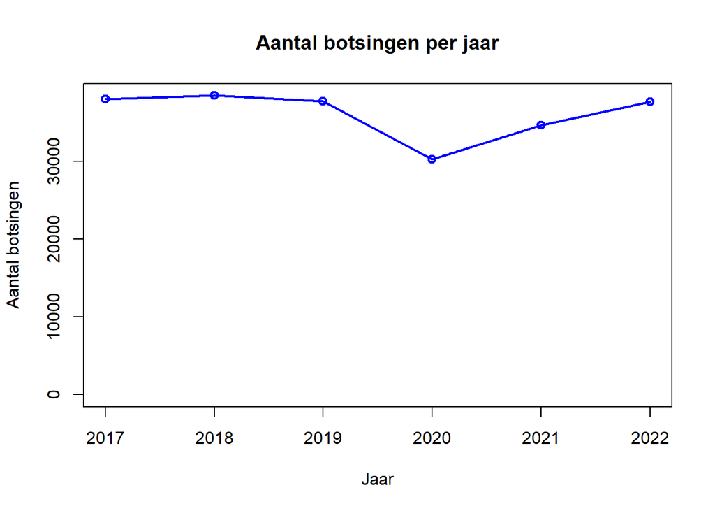

Deze grafiek toont het aantal verkeersongevallen per maand cumulatief van 2017 tot 2022. Opvallend is dat in de maanden met het meeste licht er toch de meeste ongevallen zijn, afgezien van de maanden juli en augustus. Dit is te verklaren door de zomervakantie.

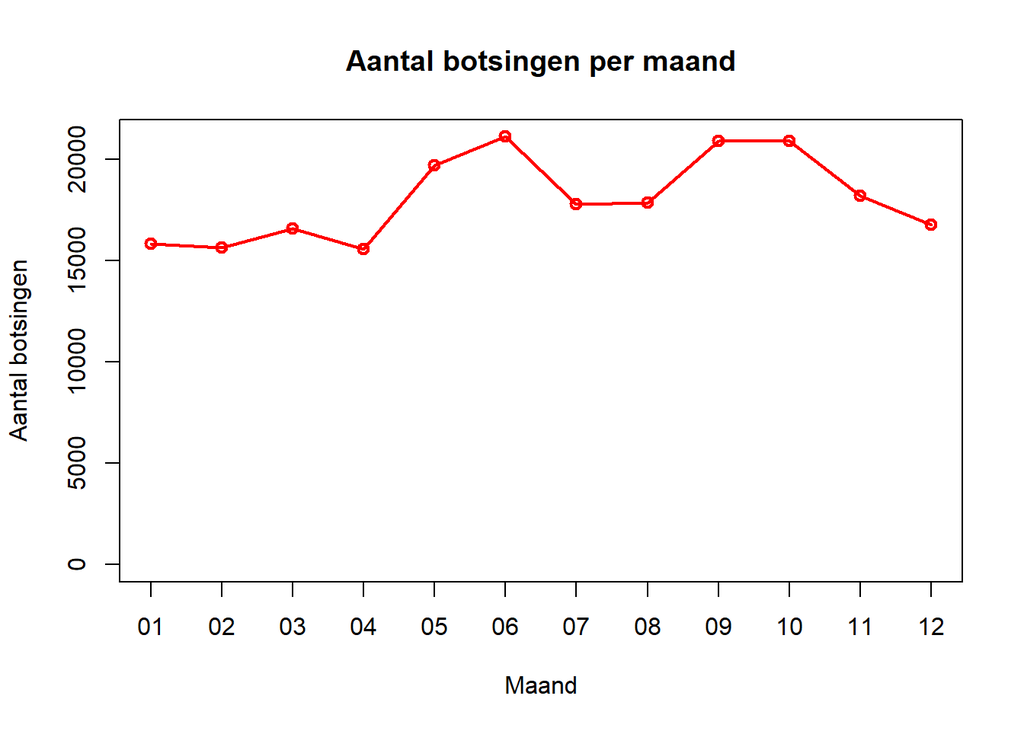

## Gefilterde data op “dodelijk gewonden” en “Met doden”

Vanaf dit punt zijn alle grafieken gemaakt op basis van data met alleen de ‘dodelijk gewonden’ en ‘met doden’. (Tenzij anders aangegeven)

```
##  DT_YEAR_COLLISION  DT_MONTH_COLLISION   DT_TIME          YEAR_MONTH_DAY
##  Length:3223        Length:3223        Length:3223        Min.   :2017-01-01
##  Class :character   Class :character   Class :character   1st Qu.:2018-06-01
##  Mode  :character   Mode  :character   Mode  :character   Median :2019-10-01
##                                                           Mean   :2019-11-09
##                                                           3rd Qu.:2021-06-01
##                                                           Max.   :2022-12-01
##
##  YEAR_MONTH_DAY_HOUR                 TIME_DT
##  Min.   :2017-01-01 00:00:00.00   Min.   :2024-01-02 00:00:00.00
##  1st Qu.:2018-06-01 15:00:00.00   1st Qu.:2024-01-02 08:00:00.00
##  Median :2019-10-01 00:00:00.00   Median :2024-01-02 14:00:00.00
##  Mean   :2019-11-09 14:21:26.43   Mean   :2024-01-02 12:45:38.27
##  3rd Qu.:2021-06-01 12:00:00.00   3rd Qu.:2024-01-02 18:00:00.00
##  Max.   :2022-12-01 21:00:00.00   Max.   :2024-01-02 23:00:00.00
##  NA's   :2                        NA's   :2
##     CD_NIS          TX_RGN_COLLISION_NL TX_PROV_COLLISION_NL
##  Length:3223        Length:3223         Length:3223
##  Class :character   Class :character    Class :character
##  Mode  :character   Mode  :character    Mode  :character
##
##
##
##
##  TX_MUNTY_COLLISION_NL   LAT_WGS84       LONG_WGS84    TX_CROSSWAY_NL
##  Length:3223           Min.   :49.55   Min.   :2.568   Length:3223
##  Class :character      1st Qu.:50.51   1st Qu.:3.931   Class :character
##  Mode  :character      Median :50.82   Median :4.470   Mode  :character
##                        Mean   :50.77   Mean   :4.506
##                        3rd Qu.:51.07   3rd Qu.:5.201
##                        Max.   :51.48   Max.   :6.311
##                        NA's   :454     NA's   :454
##  TX_WEATHER_NL      TX_ROAD_CONDITION_NL TX_BUILD_UP_AREA_NL
##  Length:3223        Length:3223          Length:3223
##  Class :character   Class :character     Class :character
##  Mode  :character   Mode  :character     Mode  :character
##
##
##
##
```

[output cut: 9 more lines]

```
##  Length:3223          Length:3223          Length:3223
##  Class :character     Class :character     Class :character
##  Mode  :character     Mode  :character     Mode  :character
##
##
##
##
##  TX_OBSTACLES_NL
##  Length:3223
##  Class :character
##  Mode  :character
##
##
##
##
```

Een klijne eerste analyse per kolom na het keusen van de data.

```
## text graphs are displayed; set 'tmp.img.dir' parameter to activate png graphs
```

### Data Frame Summary

#### gefilterde_data

**Dimensions:** 3223 x 23  
**Duplicates:** 0

| No | Variable | Stats / Values | Freqs (% of Valid) | Graph | Valid | Missing |
| --- | --- | --- | --- | --- | --- | --- |
| 1 | DT_YEAR_COLLISION [character] | 1. 2017 2. 2018 3. 2019 4. 2020 5. 2021 6. 2022 | 583 (18.1%) 568 (17.6%) 607 (18.8%) 468 (14.5%) 487 (15.1%) 510 (15.8%) | III III III II III III | 3223 (100.0%) | 0 (0.0%) |
| 2 | DT_MONTH_COLLISION [character] | 1. 07 2. 09 3. 06 4. 08 5. 11 6. 05 7. 10 8. 02 9. 12 10. 04 [ 2 others ] | 316 ( 9.8%) 314 ( 9.7%) 289 ( 9.0%) 285 ( 8.8%) 271 ( 8.4%) 268 ( 8.3%) 266 ( 8.3%) 252 ( 7.8%) 251 ( 7.8%) 247 ( 7.7%) 464 (14.4%) | I I I I I I I I I I II | 3223 (100.0%) | 0 (0.0%) |
| 3 | DT_TIME [character] | 1. 15 2. 16 3. 17 4. 18 5. 14 6. 13 7. 11 8. 20 9. 19 10. 10 [ 15 others ] | 223 ( 6.9%) 214 ( 6.6%) 206 ( 6.4%) 202 ( 6.3%) 180 ( 5.6%) 179 ( 5.6%) 157 ( 4.9%) 156 ( 4.8%) 152 ( 4.7%) 146 ( 4.5%) 1408 (43.7%) | I I I I I I IIIIIIII | 3223 (100.0%) | 0 (0.0%) |
| 4 | YEAR_MONTH_DAY [Date] | min : 2017-01-01 med : 2019-10-01 max : 2022-12-01 range : 5y 11m 0d | 72 distinct values | **: : . : .\** : : : : . : : : : : : : : : : : : : : : : : : : : : : : : : : : : : : : | 3223 (100.0%) | 0 (0.0%) |
| 5 | YEAR_MONTH_DAY_HOUR [POSIXct, POSIXt] | min : 2017-01-01 med : 2019-10-01 max : 2022-12-01 21:00:00 range : 5y 11m 0d 21H 0M 0S | 1405 distinct values | **: : . : .\** : : : : . : : : : : : : : : : : : : : : : : : : : : : : : : : : : : : : | 3221 (99.9%) | 2 (0.1%) |
| 6 | TIME_DT [POSIXct, POSIXt] | min : 2024-01-02 med : 2024-01-02 14:00:00 max : 2024-01-02 23:00:00 range : 23H 0M 0S | 24 distinct values | : : . : . . : : . . : . : : : : : : : : : : : : : : : : : | 3221 (99.9%) | 2 (0.1%) |
| 7 | CD_NIS [character] | 1. 11002 2. 52011 3. 44021 4. 92094 5. 53053 6. 21004 7. 62063 8. 57081 9. 31005 10. 46003 [ 527 others ] | 88 ( 2.7%) 46 ( 1.4%) 43 ( 1.3%) 39 ( 1.2%) 38 ( 1.2%) 37 ( 1.1%) 37 ( 1.1%) 36 ( 1.1%) 35 ( 1.1%) 23 ( 0.7%) 2801 (86.9%) | IIIIIIIIIIIIIIIII | 3223 (100.0%) | 0 (0.0%) |
| 8 | TX_RGN_COLLISION_NL [character] | 1. Brussels Hoofdstedelijk G 2. Vlaams Gewest 3. Waals Gewest | 108 ( 3.4%) 1680 (52.1%) 1435 (44.5%) | IIIIIIIIII IIIIIIII | 3223 (100.0%) | 0 (0.0%) |
| 9 | TX_PROV_COLLISION_NL [character] | 1. Provincie Antwerpen 2. Provincie Henegouwen 3. Provincie Limburg 4. Provincie Luik 5. Provincie Luxemburg 6. Provincie Namen 7. Provincie Oost-Vlaanderen 8. Provincie Vlaams-Brabant 9. Provincie Wa… | 418 (13.4%) 482 (15.5%) 291 ( 9.3%) 389 (12.5%) 191 ( 6.1%) 275 ( 8.8%) 370 (11.9%) 231 ( 7.4%) 98 ( 3.1%) 370 (11.9%) | II III I II I I II I II | 3115 (96.6%) | 108 (3.4%) |
| 10 | TX_MUNTY_COLLISION_NL [character] | 1. Antwerpen 2. Charleroi 3. Gent 4. Namen 5. Bergen 6. Brussel 7. Luik 8. Doornik 9. Brugge 10. Beveren (Sint-Niklaas) [ 527 others ] | 88 ( 2.7%) 46 ( 1.4%) 43 ( 1.3%) 39 ( 1.2%) 38 ( 1.2%) 37 ( 1.1%) 37 ( 1.1%) 36 ( 1.1%) 35 ( 1.1%) 23 ( 0.7%) 2801 (86.9%) | IIIIIIIIIIIIIIIII | 3223 (100.0%) | 0 (0.0%) |
| 11 | LAT_WGS84 [numeric] | Mean (sd) : 50.8 (0.4) min < med < max: 49.6 < 50.8 < 51.5 IQR (CV) : 0.6 (0) | 2745 distinct values | . : : : : : : : : : : : : : . : : : : : . . . : : : : : : : | 2769 (85.9%) | 454 (14.1%) |
| 12 | LONG_WGS84 [numeric] | Mean (sd) : 4.5 (0.8) min < med < max: 2.6 < 4.5 < 6.3 IQR (CV) : 1.3 (0.2) | 2745 distinct values | : : . : : : . : : : : : : . : : : : : : . | 2769 (85.9%) | 454 (14.1%) |
| 13 | TX_CROSSWAY_NL [character] | 1. Buiten Kruispunt 2. onbekend 3. Op Kruispunt | 2566 (79.6%) 4 ( 0.1%) 653 (20.3%) | IIIIIIIIIIIIIII IIII | 3223 (100.0%) | 0 (0.0%) |
| 14 | TX_WEATHER_NL [character] | 1. Normaal 2. Regenval 3. Onbekend 4. Mist (zichtbaarheid minde 5. Sterke wind, rukwind 6. Sneeuwval 7. Andere (dikke rook,…) 8. Regenval+Sterke wind, ruk 9. Hagelbui 10. Regenval+Sneeuwval [ 3 others… | 2705 (83.9%) 301 ( 9.3%) 131 ( 4.1%) 21 ( 0.7%) 21 ( 0.7%) 17 ( 0.5%) 13 ( 0.4%) 8 ( 0.2%) 2 ( 0.1%) 1 ( 0.0%) 3 ( 0.1%) | IIIIIIIIIIIIIIII I | 3223 (100.0%) | 0 (0.0%) |
| 15 | TX_ROAD_CONDITION_NL [character] | 1. Droog 2. Nat, plassen 3. Proper 4. Droog+Proper 5. Onbekend 6. Nat, plassen+Proper 7. Vuil (zand, grint, blader 8. Ijzel, sneeuw 9. Nat, plassen+Ijzel of sne 10. Nat, plassen+Vuil (zand, [ 3 others… | 1708 (53.0%) 604 (18.7%) 436 (13.5%) 316 ( 9.8%) 63 ( 2.0%) 39 ( 1.2%) 22 ( 0.7%) 21 ( 0.7%) 4 ( 0.1%) 4 ( 0.1%) 6 ( 0.2%) | IIIIIIIIII III II I | 3223 (100.0%) | 0 (0.0%) |
| 16 | TX_BUILD_UP_AREA_NL [character] | 1. binnen bebouwde kom 2. buiten bebouwde kom 3. onbekend | 1119 (34.7%) 2074 (64.3%) 30 ( 0.9%) | IIIIII IIIIIIIIIIII | 3223 (100.0%) | 0 (0.0%) |
| 17 | TX_LIGHT_CONDITION_NL [character] | 1. Dag 2. Dageraad - schemering 3. Nacht, geen openbare verl 4. Nacht, openb. verlicht. a 5. Nacht, openbare verlichti 6. Onbekend | 1935 (60.0%) 151 ( 4.7%) 236 ( 7.3%) 56 ( 1.7%) 807 (25.0%) 38 ( 1.2%) | IIIIIIIIIIII I IIIII | 3223 (100.0%) | 0 (0.0%) |
| 18 | CD_ROAD_TYPE_NL [character] | 1. Autosnelweg 2. Gemeenteweg 3. Gewestweg 4. onbekend | 509 (15.8%) 1049 (32.5%) 1643 (51.0%) 22 ( 0.7%) | III IIIIII IIIIIIIIII | 3223 (100.0%) | 0 (0.0%) |
| 19 | TX_CLASS_ACCIDENTS_NL [character] | 1. dodelijk gewonden 2. Met doden | 819 (25.4%) 2404 (74.6%) | IIIII IIIIIIIIIIIIII | 3223 (100.0%) | 0 (0.0%) |
| 20 | TX_ROAD_USR_TYPE1_NL [character] | 1. Andere weggebruiker 2. Autobus 3. Bromfiets 4. Fiets 5. Lichte vrachtauto 6. Motorfiets 7. onbekend 8. personenauto 9. Voetganger 10. Vrachtwagen | 84 ( 2.6%) 23 ( 0.7%) 68 ( 2.1%) 236 ( 7.3%) 199 ( 6.2%) 329 (10.2%) 154 ( 4.8%) 1768 (54.9%) 63 ( 2.0%) 299 ( 9.3%) | I I II IIIIIIIIII I | 3223 (100.0%) | 0 (0.0%) |
| 21 | TX_ROAD_USR_TYPE2_NL [character] | 1. een weggebruiker tegen ee 2. personenauto 3. Voetganger 4. Fiets 5. Vrachtwagen 6. één bestuurder, geen hind 7. onbekend 8. Motorfiets 9. Lichte vrachtauto 10. Andere weggebruiker [ 2 others ] | 1025 (31.8%) 600 (18.6%) 386 (12.0%) 264 ( 8.2%) 256 ( 7.9%) 205 ( 6.4%) 152 ( 4.7%) 124 ( 3.8%) 80 ( 2.5%) 61 ( 1.9%) 70 ( 2.2%) | IIIIII III II I I I | 3223 (100.0%) | 0 (0.0%) |
| 22 | TX_COLLISION_TYPE_NL [character] | 1. Andere of onbekend 2. Eén bestuurder, geen hind 3. Geen vermelding van de ty 4. Kettingbotsing (3 bestuur 5. Met een voetganger 6. Tss. 2 best.: langs opzij 7. Tussen 2 bestuurders: Fla 8. Tussen 2… | 74 ( 2.3%) 205 ( 6.4%) 76 ( 2.4%) 77 ( 2.4%) 451 (14.0%) 531 (16.5%) 101 ( 3.1%) 346 (10.7%) 337 (10.5%) 957 (29.7%) 68 ( 2.1%) | I II III II II IIIII | 3223 (100.0%) | 0 (0.0%) |
| 23 | TX_OBSTACLES_NL [character] | 1. Geen hindernis 2. Buiten de rijbaan: Boom 3. Buiten de rijbaan: Andere 4. Buiten de rijbaan: Muur g 5. Andere hindernis 6. Geen vermelding van de aa 7. Geen vermelding van de ty 8. Buiten de rijbaa… | 2043 (63.4%) 304 ( 9.4%) 119 ( 3.7%) 113 ( 3.5%) 100 ( 3.1%) 79 ( 2.5%) 76 ( 2.4%) 75 ( 2.3%) 59 ( 1.8%) 55 ( 1.7%) 200 ( 6.2%) | IIIIIIIIIIII I I | 3223 (100.0%) | 0 (0.0%) |

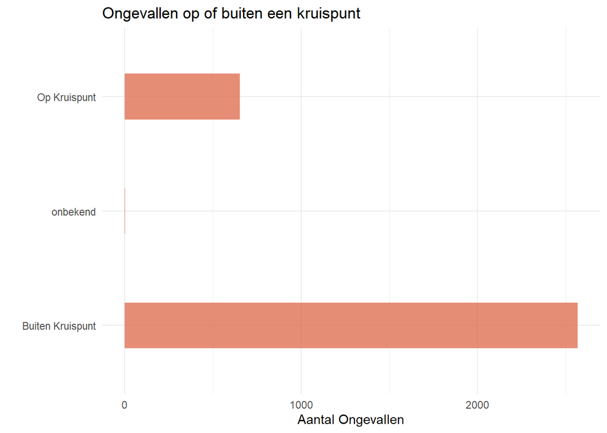

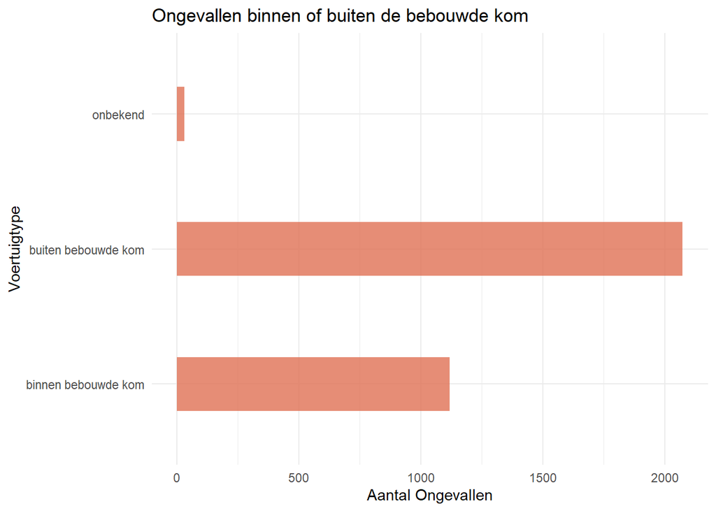

De onderstaande lijngrafiek toont het aantal verkeersdoden per jaar van 2017 tot 2022. Uiteraard is er een dip in 2020; de jaren nadien is er een lichte stijging, maar niet dezelfde stijging als in de grafiek met alle ongevallen.

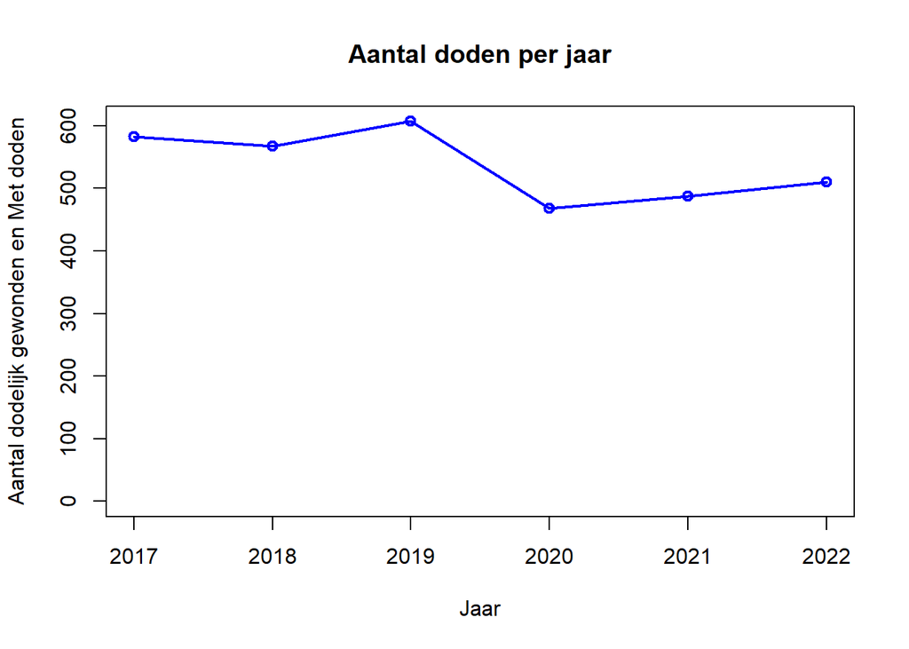

Als we kijken naar het aantal verkeersongevallen per maand cumulatief van 2017 tot 2022, valt op dat juli een piekmaand is, in tegenstelling tot de grafiek met alle ongevallen.

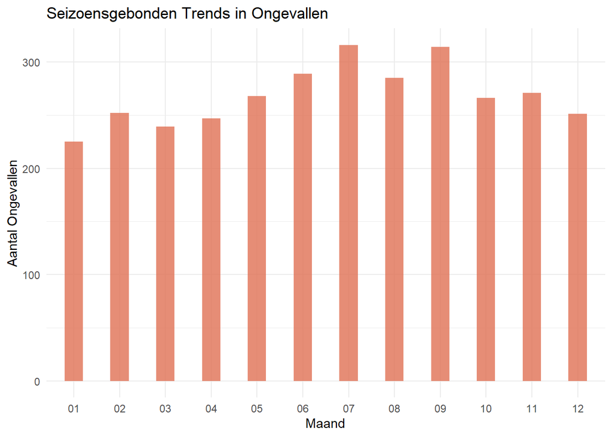

Evolutie van het aantal dodelijke ongevallen van 2017 tot 2022. De piekmaanden zijn 2018-07-01 met 72 en 2020-09-01 met 71.

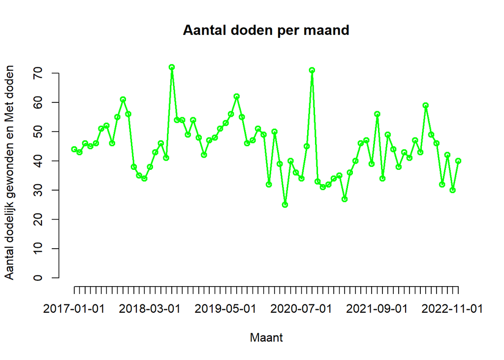

### Licht en donker

Aantal verkeersdoden per uur cumulatief van 2017 tot 2022. De meeste dodelijke ongevallen gebeuren in de late namiddag vroege avond.

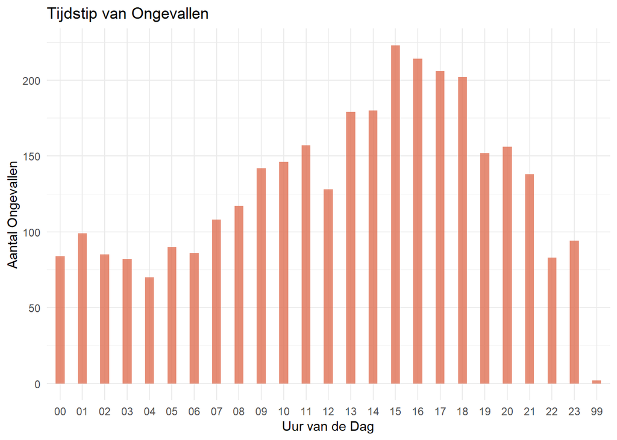

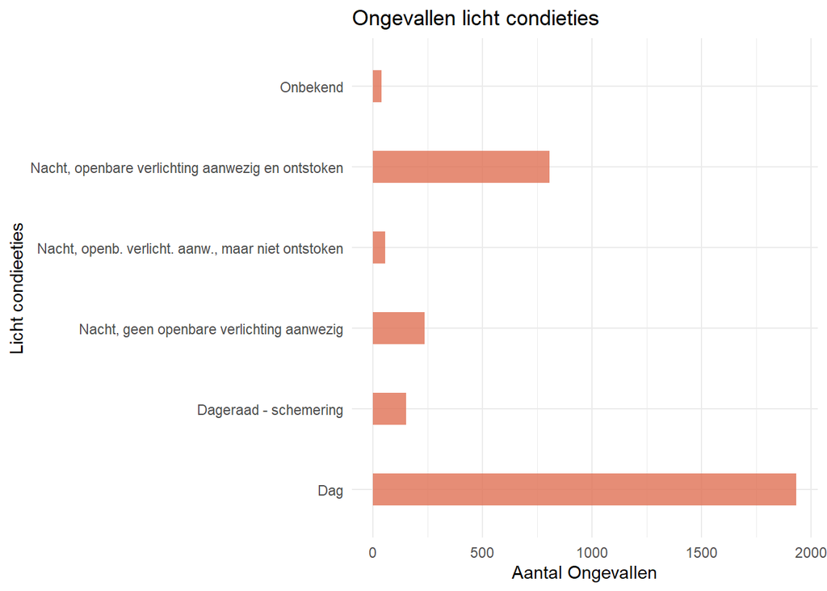

### Nat en droog

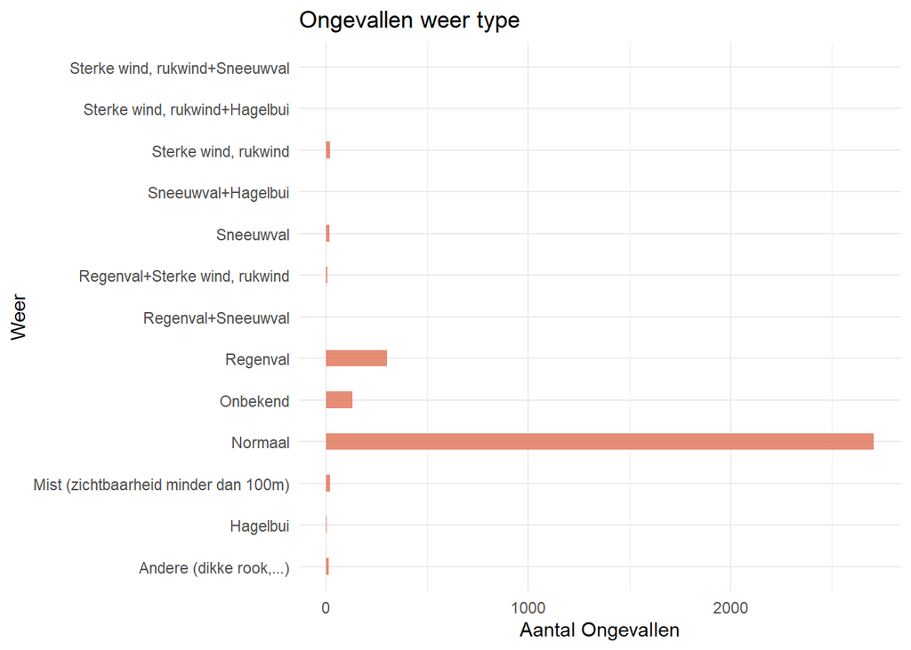

De zelfde grfiek maar zonder “Normaal”

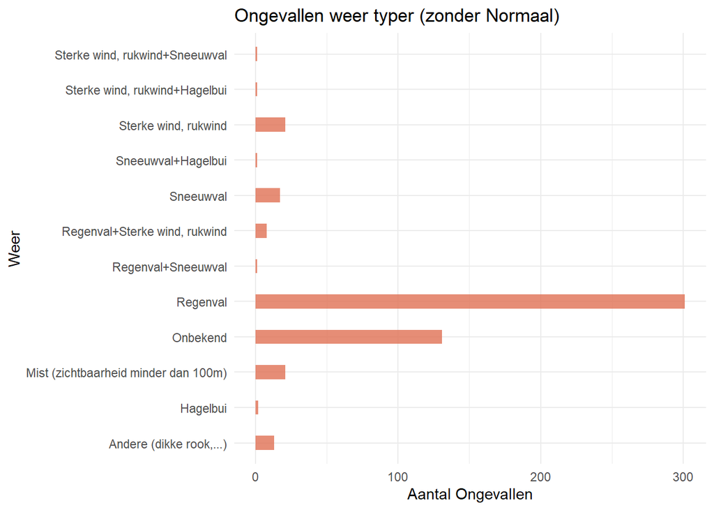

Hoe is de staat van de weg.

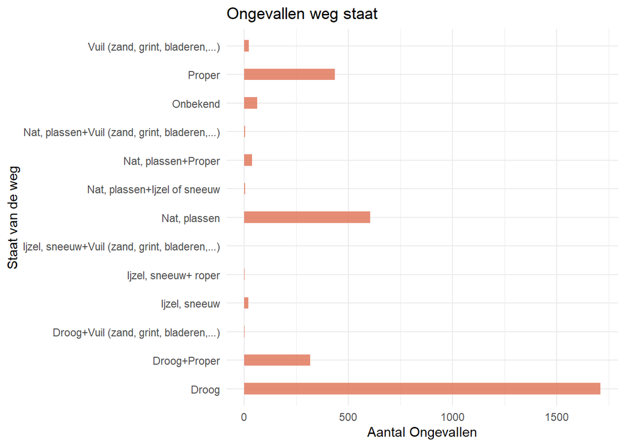

[interactive chart not shown]

## Ter plaatse overleden of binnen 30 dagen na het ongeval

In de onderstaande grafiek kijken we naar het aantal mensen dat ter plaatse is overleden en het aantal mensen dat binnen 30 dagen na het ongeval is overleden.

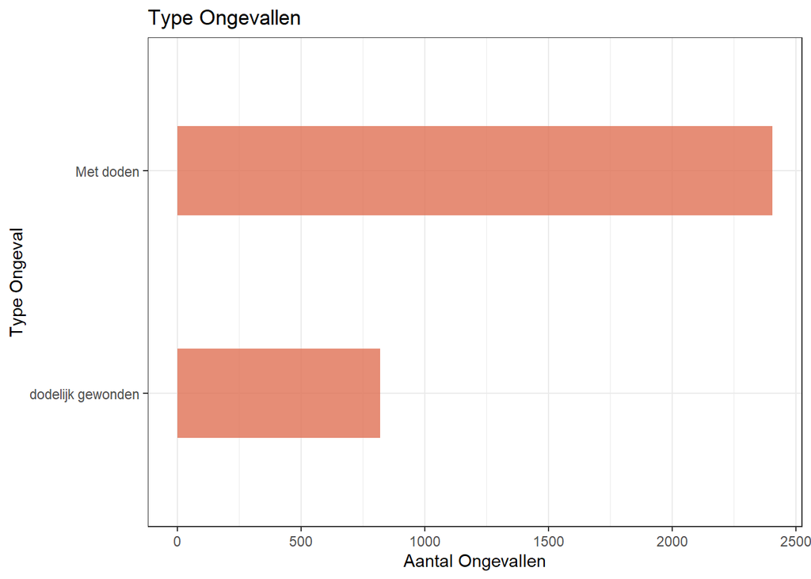

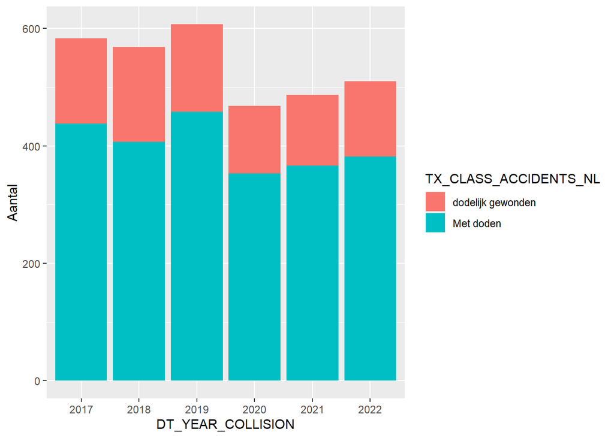

Als we dit afzetten tegenover 100%, zien we dat het aantal mensen dat ter plaatse sterft rond de 75% blijft.

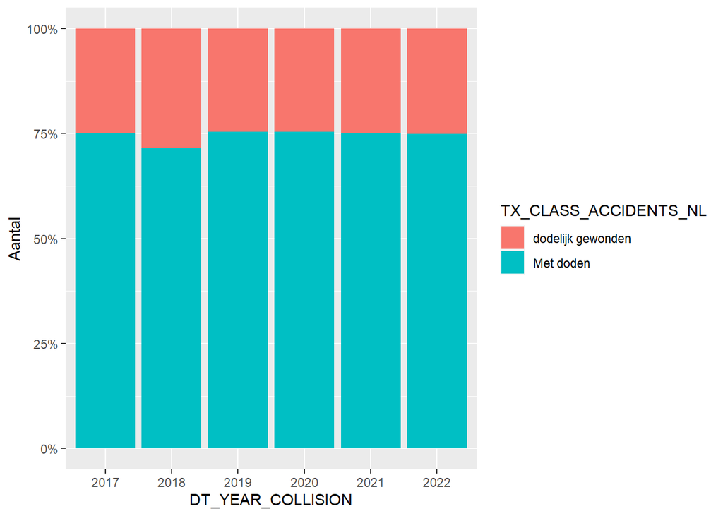

Hier onder doen we het zlefd maar maandelijks

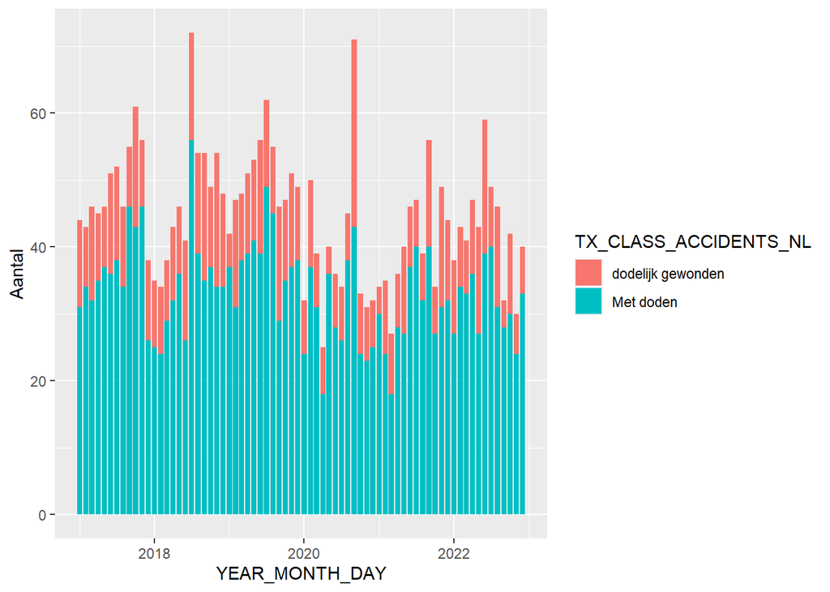

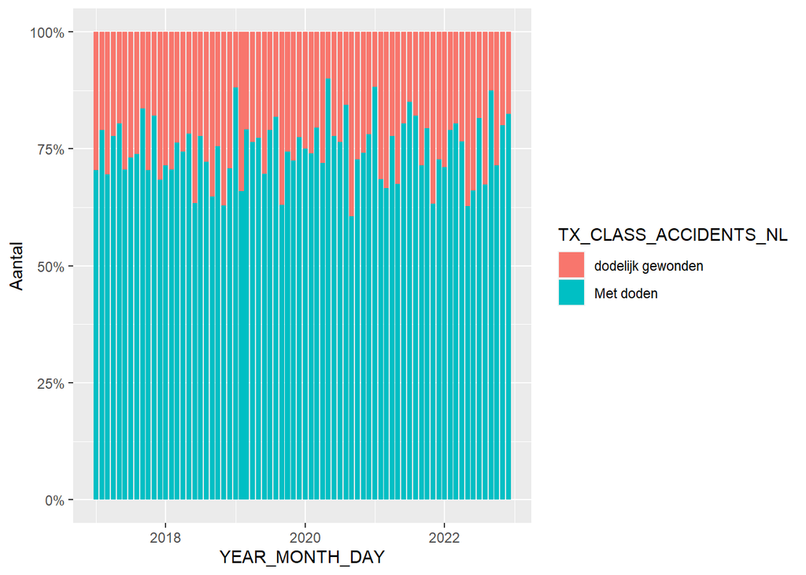

De volgende twee grefieken tonen het typer van voertuigen die betrokken zijn bij het ongeval. In de eerste zien je typer 1 en in de volgende zie je type 2.

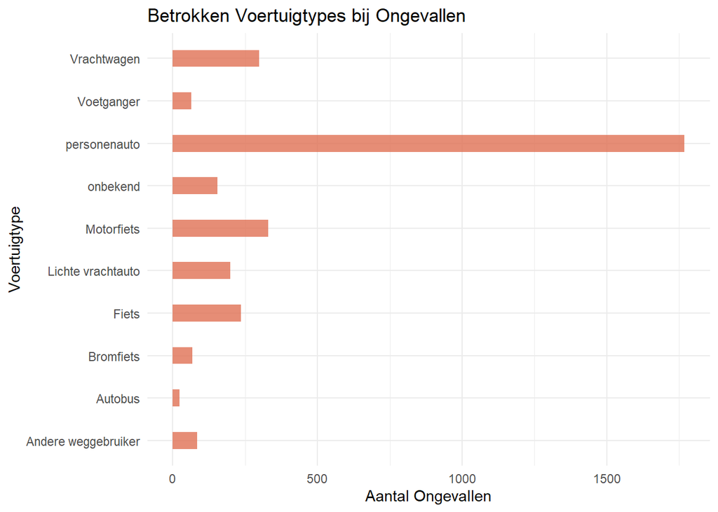

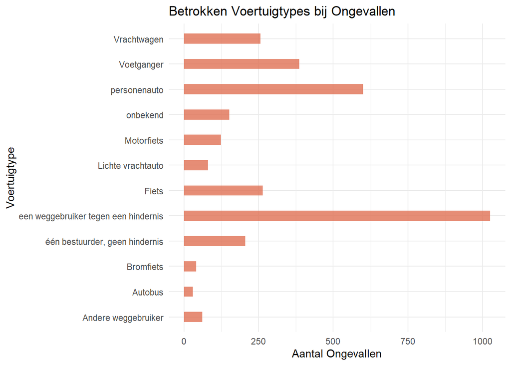

Het onderstaande Sankey-diagram illustreert de stroom van verkeersongevallen, van type 1 (links) naar type 2 (rechts). Deze visualisatie benadrukt dat vooral personewagens betrokken zijn bij ongevallen.

[interactive chart not shown]

Dit is de zelfde visualisatie maar als headmap.

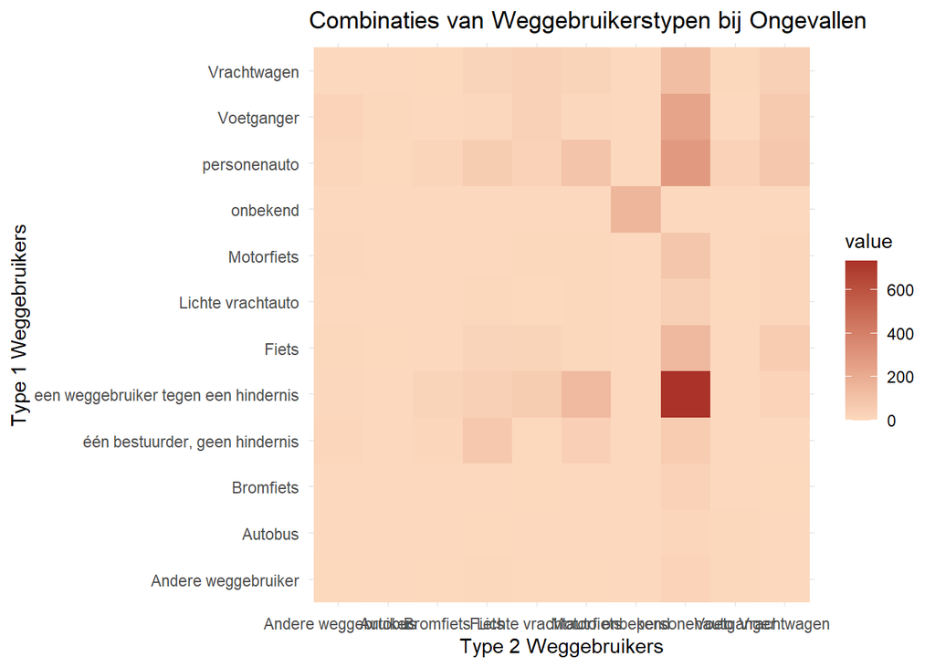

We gebruiken een gestapelde staafdiagram om de proporties van ongevallen per weggebruikerstype te visualiseren. De grafiek toont het percentage van ongevallen voor elke combinatie van ‘Type 1’ en ‘Type 2’ weggebruikers, wat ons helpt te begrijpen welke combinaties het meest voorkomen en potentieel gevaarlijk zijn.

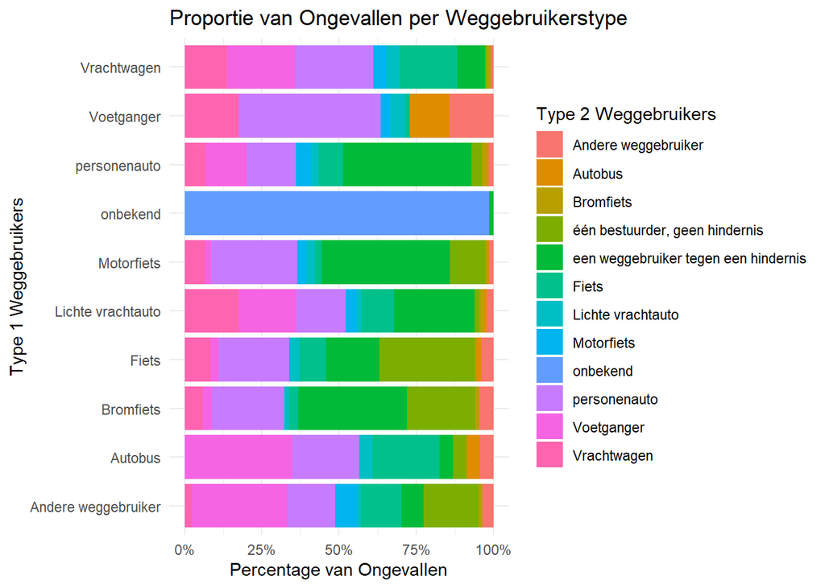

Het onderstaande Sankey-diagram illustreert de stroom van verkeersongevallen, van provincies (links) naar wegtypen (rechts). Deze visualisatie benadrukt niet alleen de verdeling van dodelijke ongevallen, maar laat ook zien dat de meeste ongevallen voornamelijk plaatsvinden op gewestwegen.

[interactive chart not shown]

bij de volgende gragieken probeerde ik het zelfde om andere conecties te vinden zonder veel succes.

[interactive chart not shown]

## Gemeenten

Hier zien we welke gemeentes er de meeste dodelijke ongevallen hebben per weg type.

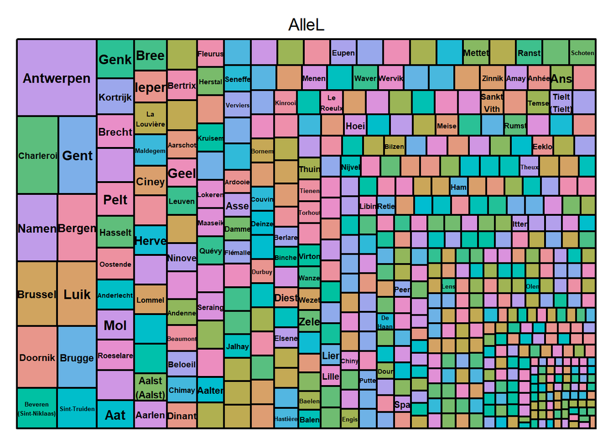

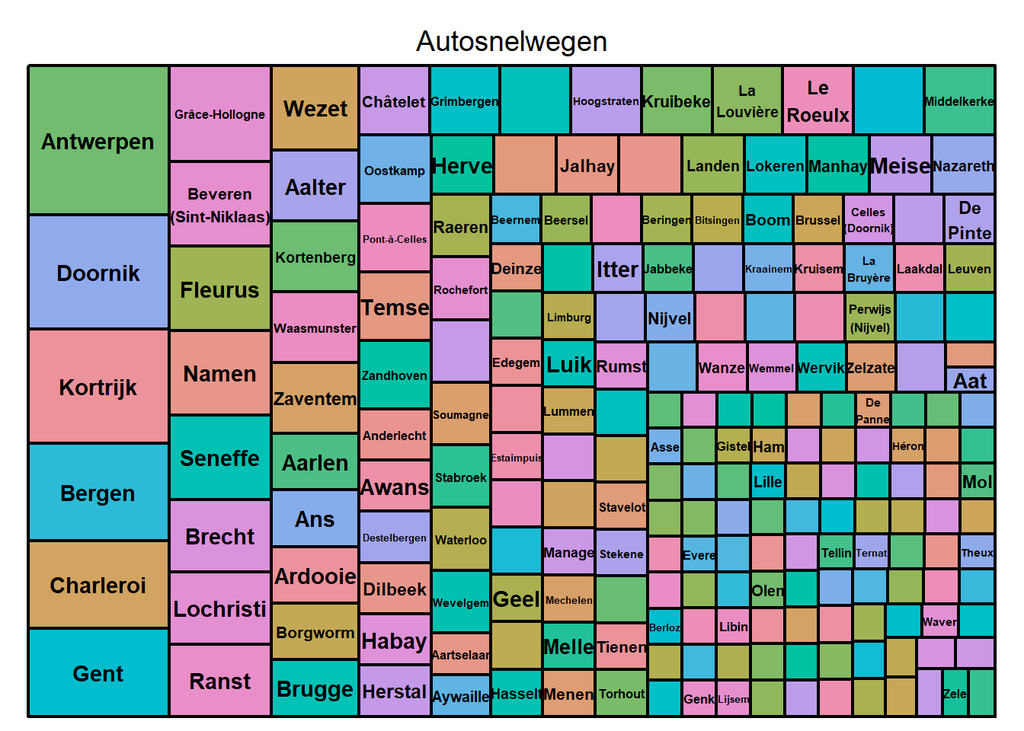

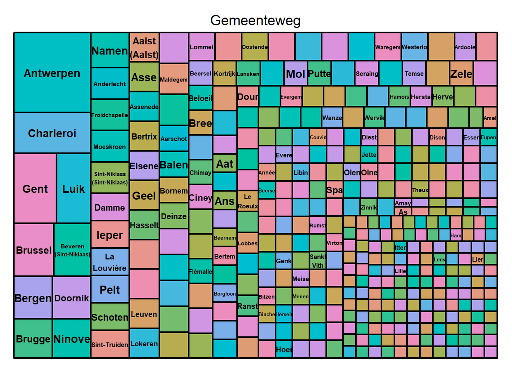

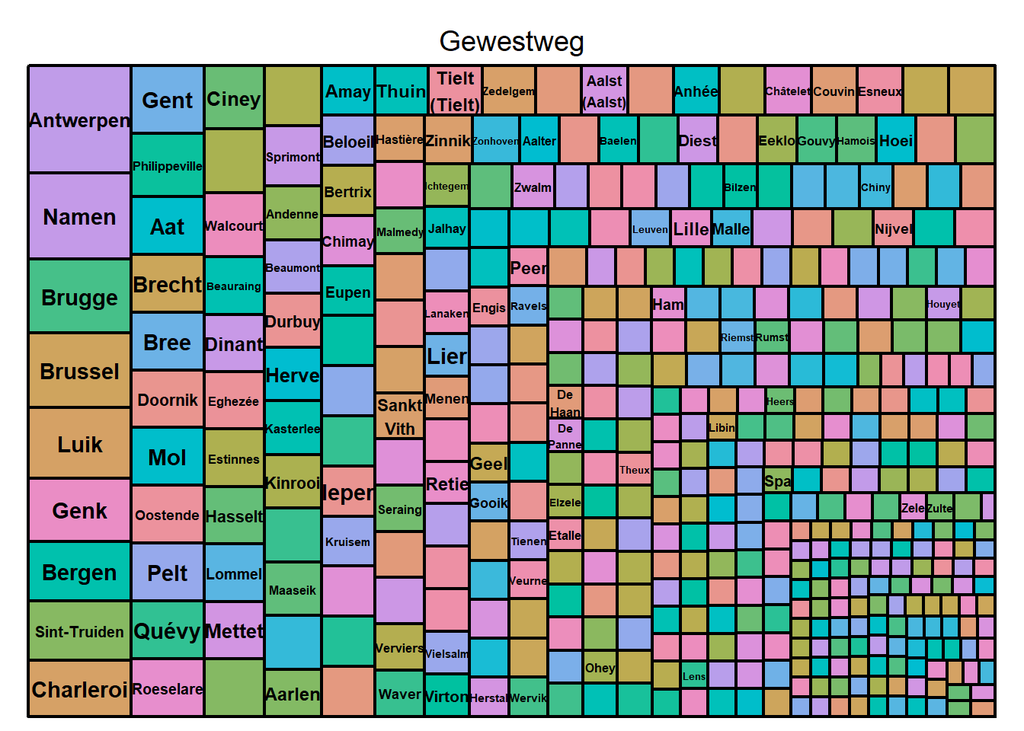

### Clusters

De onderstaande kaart toont alle dodelijke ongevallen die zich hebben voorgedaan binnen een straal van 50 meter van elkaar.

Maar ik ben niet de enige die hieraan heeft gedacht. Bekijk de link voor de situering van verkeersongevallen: https://statbel.fgov.be/nl/themas/mobiliteit/verkeer/verkeersongevallen#panel-15

Zie de link voor alle zwarte punten in Vlaanderen: https://www.vlaanderen.be/gevaarlijke-punten

[interactive chart not shown]

### Per gemeente

Omdat ik deze data niet zo goed kan weergeven als in Datawrapper, hier zijn de links naar de gemeentekaarten en het aantal doden per wegtype.

[Gewestweg](https://www.datawrapper.de/_/BuPT9/) [Gemeenteweg](https://www.datawrapper.de/_/eLKZU/) [Autosnelweg](https://www.datawrapper.de/_/tMNzn/)